Nada Ardelia  
G1401231011

# Library

```r
library(ggplot2)
library(tsibble)
library(tseries)
library(MASS)
```

```r
library(lattice)
library(dplyr)
```

# Data

```r
data <- read.csv("C:\\Users\\ailed\\Downloads\\Telur Ayam Ras.csv")
head(data)
```

```
##         Date Jawa.Barat
## 1 2022-07-14      27680
## 2 2022-07-15      27920
## 3 2022-07-16      27960
## 4 2022-07-17      27890
## 5 2022-07-18      27950
## 6 2022-07-19      28260
```

```r
data_subset <- data[160:319, ]
head(data_subset)
```

```
##           Date Jawa.Barat
## 160 2022-12-20      30500
## 161 2022-12-21      30400
## 162 2022-12-22      30200
## 163 2022-12-23      29880
## 164 2022-12-24      29810
## 165 2022-12-25      30050
```

```r
data_subset$Date <- as.Date(data_subset$Date)
```

# Plot Time Series

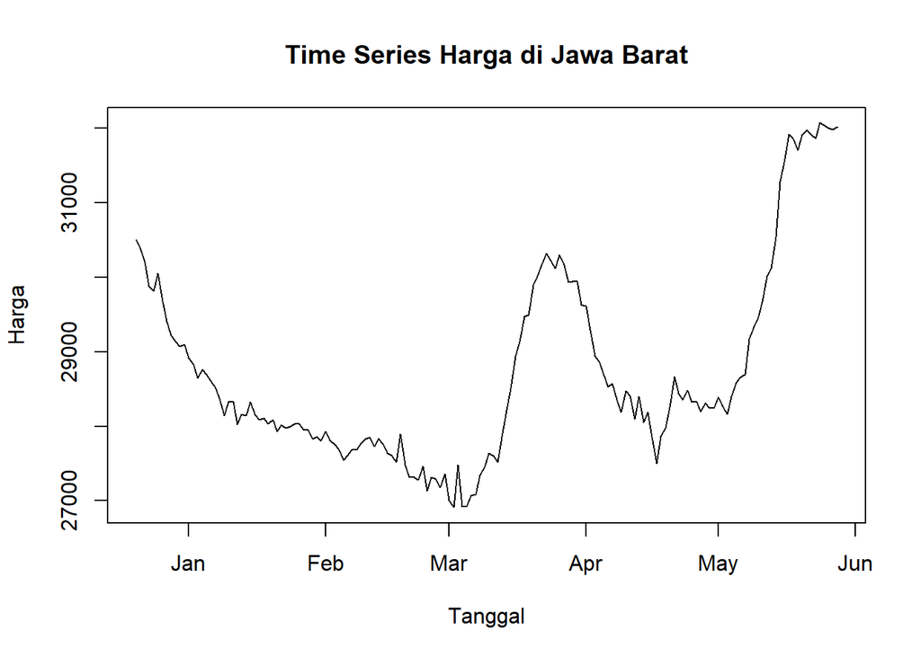

```r
plot(data_subset$Date, data_subset$Jawa.Barat, type = "l",
     xlab = "Tanggal", ylab = "Harga", main = "Time Series Harga di Jawa Barat")
```

```r
mean(data_subset$Jawa.Barat, na.rm = TRUE)
```

```
## [1] 28737
```

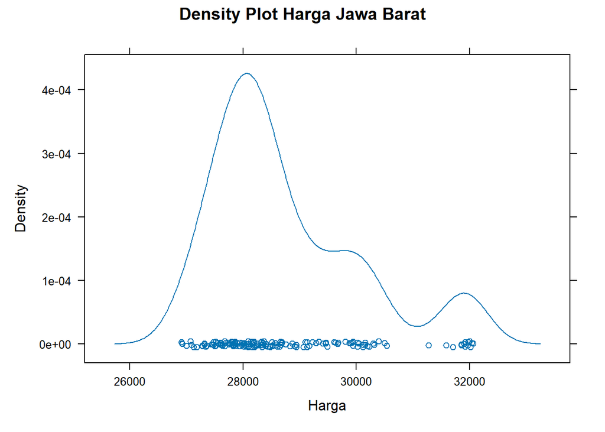

```r
densityplot(as.vector(data_subset$Jawa.Barat),
            main = "Density Plot Harga Jawa Barat",
            xlab = "Harga")
```

Plot Time Series dan Density Plot di atas menunjukkan bahwa data tidak stasioner terhadap rataan.

# Plot ACF

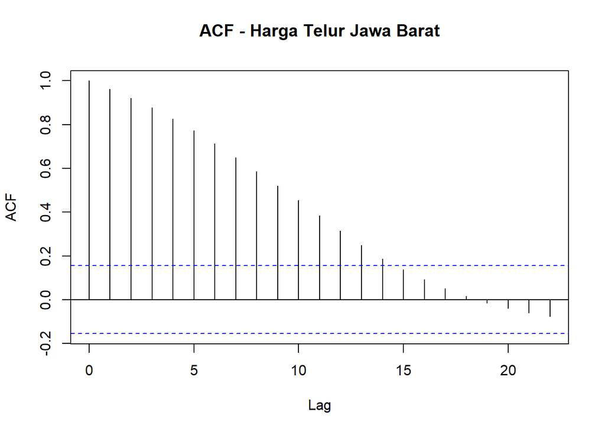

```r
harga <- na.omit(data_subset$Jawa.Barat)
acf(harga, main = "ACF - Harga Telur Jawa Barat")
```

Berdasarkan plot ACF, terlihat bahwa plot ACF pada data tersebut cenderung tails off.

# Uji ADF

$H_0$: Data tidak stasioner dalam rataan

$H_1$: Data stasioner dalam rataan

```r
tseries::adf.test(harga)
```

```
##
##  Augmented Dickey-Fuller Test
##
## data:  harga
## Dickey-Fuller = -2.6548, Lag order = 5, p-value = 0.3032
## alternative hypothesis: stationary
```

# Plot Box Cox

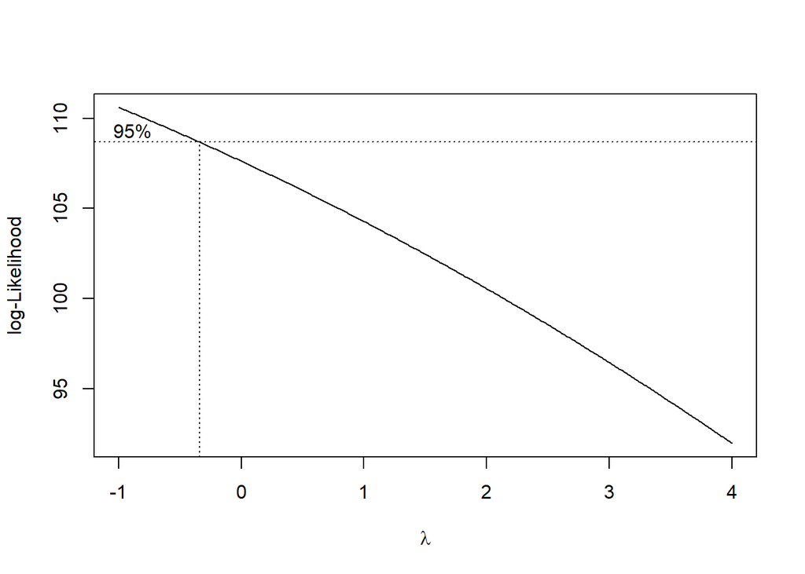

```r
index <- seq_along(harga)

# Plot Box-Cox
bc <- boxcox(harga ~ index, lambda = seq(-1, 4, by = 0.01))
```

```r
# Nilai lambda maksimum (optimum)
lambda <- bc$x[which.max(bc$y)]
lambda
```

```
## [1] -1
```

```r
# Hitung selang kepercayaan 95%

# CI lambda: nilai log-likelihood maksimum - chi-square
ci_lambda <- bc$x[bc$y > max(bc$y) - 0.5 * qchisq(0.95, 1)]

# Batas bawah dan atas
ci_lower <- min(ci_lambda)
ci_upper <- max(ci_lambda)

# Tampilkan hasil
c(Batas_Bawah = ci_lower, Batas_Atas = ci_upper)
```

```
## Batas_Bawah  Batas_Atas
##       -1.00       -0.35
```

Gambar di atas menunjukkan nilai λ optimum (rounded value) sebesar -1 dan selang kepercayaan 95% nilai memiliki batas bawah -1 dan batas atas -0,35. Selang tersebut *tidak memuat nilai satu* sehingga dapat dikatakan bahwa data harga *tidak stasioner dalam ragam*.

> Data tidak stasioner dalam rataan dan ragam sehingga perlu penanganan lebih lanjut. Penanganan pertama adalah stasionerkan ragam terlebih dahulu dengan transformasi Box-Cox, lalu differencing.

> Jika step diawalin dengan diff dulu, bisa menyebabkan data jadi negatif sehingga ga bisa pakai transformasi Box-Cox.

# Transformasi Box-Cox

```r
model_bc <- lm(harga ~ 1)
```

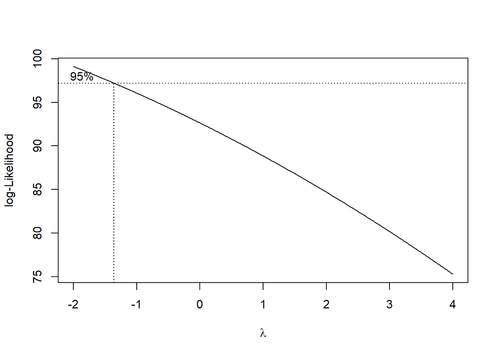

```r
bc <- boxcox(model_bc, lambda = seq(-2, 4, by = 0.01))
```

```r
lambda_opt <- bc$x[which.max(bc$y)]
lambda_opt
```

```
## [1] -2
```

```r
ci_lambda <- bc$x[bc$y > max(bc$y) - 0.5 * qchisq(0.95, 1)]
ci_lower <- min(ci_lambda)
ci_upper <- max(ci_lambda)
```

```r
c(Batas_Bawah = ci_lower, Batas_Atas = ci_upper)
```

```
## Batas_Bawah  Batas_Atas
##       -2.00       -1.36
```

Setelah transformasi Box-Cox nilai 1 tetap tidak dalam rentang.

# Differencing 1

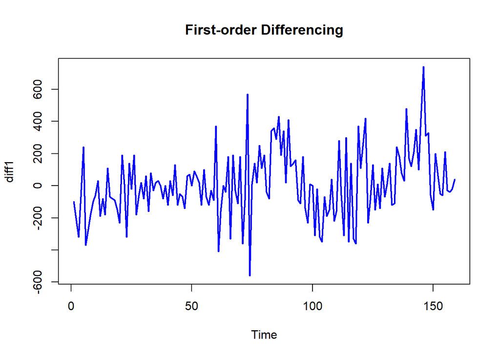

```r
diff1 <- diff(harga, differences = 1)
plot.ts(diff1, main = "First-order Differencing", col = "blue", lwd = 2)
```

## Uji ADF

```r
adf.test(diff1)
```

```
##
##  Augmented Dickey-Fuller Test
##
## data:  diff1
## Dickey-Fuller = -3.2075, Lag order = 5, p-value = 0.08913
## alternative hypothesis: stationary
```

p-value > 0,05 sehingga masih tidak stasioner, maka akan coba differencing ke 2 kali.

# Differencing 2

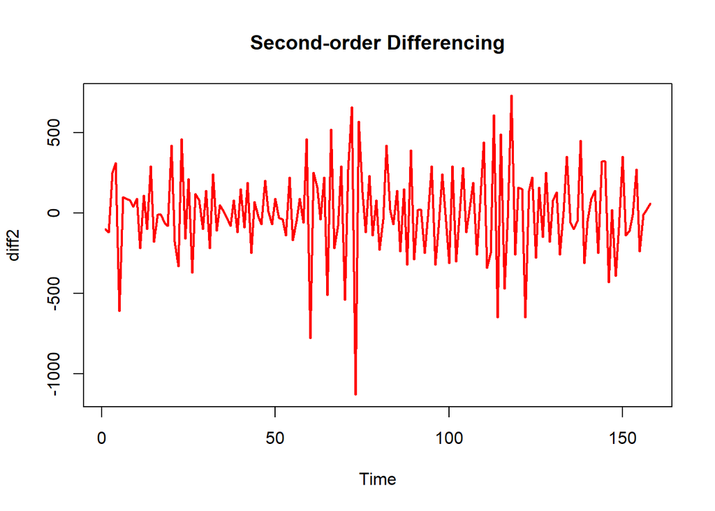

```r
diff2 <- diff(harga, differences = 2)
plot.ts(diff2, main = "Second-order Differencing", col = "red", lwd = 2)
```

## Uji ADF

```r
adf.test(diff2)
```

```
##
##  Augmented Dickey-Fuller Test
##
## data:  diff2
## Dickey-Fuller = -7.6373, Lag order = 5, p-value = 0.01
## alternative hypothesis: stationary
```

## Plot ACF

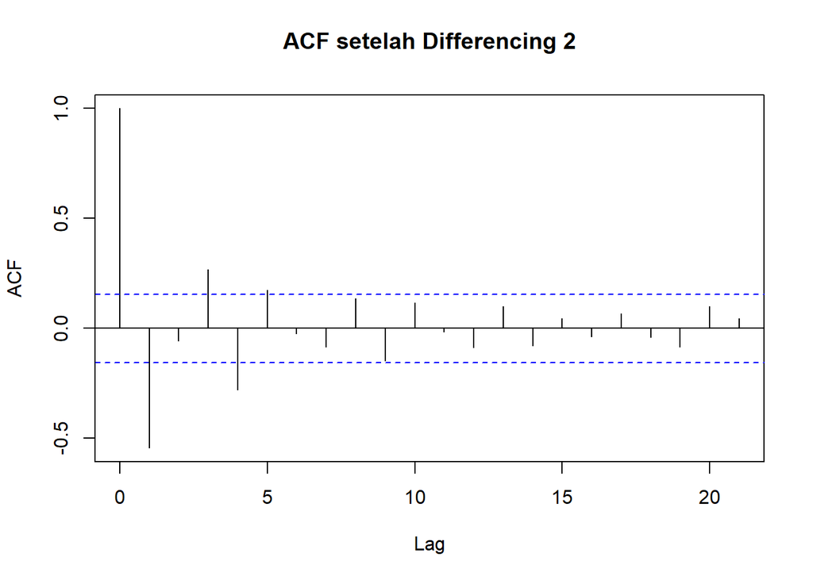

```r
acf(diff2, main = "ACF setelah Differencing 2")
```

Data sudah stasioner terhadap rataan, namun masih non stasioner terhadap ragam.

# Partisi Data

```r
n <- nrow(data_subset)
train_size <- floor(0.8 * n)

# Bagi data
train_data <- data_subset[1:train_size, ]
test_data  <- data_subset[(train_size+1):n, ]

# Cek jumlah baris
nrow(train_data)
```

```
## [1] 128
```

```r
nrow(test_data)
```

```
## [1] 32
```

## Data Train

```r
train_data$Date <- as.Date(train_data$Date)
```

### Plot Time Series

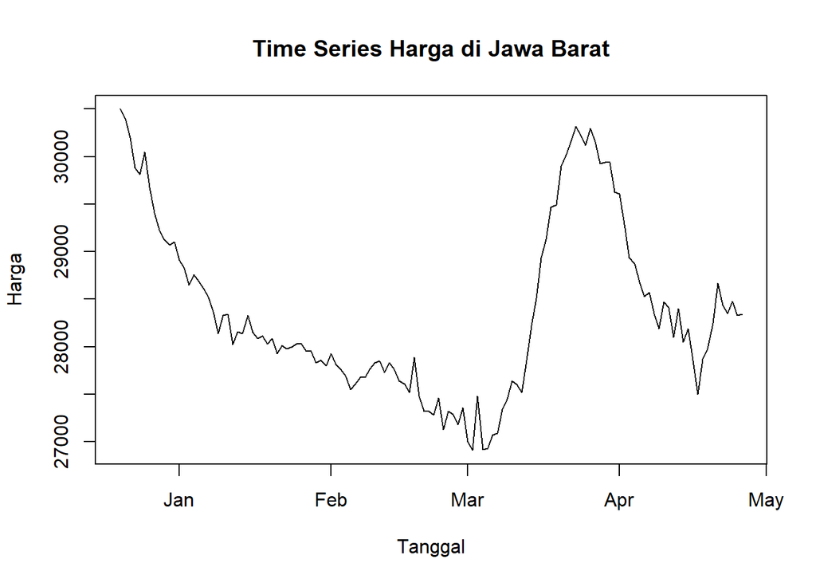

```r
plot(train_data$Date, train_data$Jawa.Barat, type = "l",
     xlab = "Tanggal", ylab = "Harga", main = "Time Series Harga di Jawa Barat")
```

```r
mean(train_data$Jawa.Barat, na.rm = TRUE)
```

```
## [1] 28369.69
```

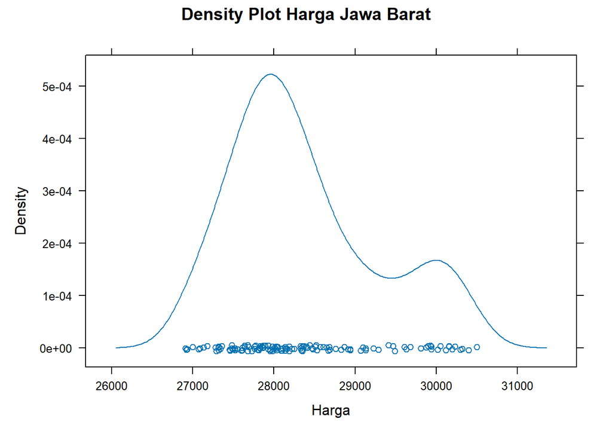

```r
densityplot(as.vector(train_data$Jawa.Barat),
            main = "Density Plot Harga Jawa Barat",
            xlab = "Harga")
```

Plot Time Series dan Density Plot di atas menunjukkan bahwa data tidak stasioner terhadap rataan.

### Plot ACF

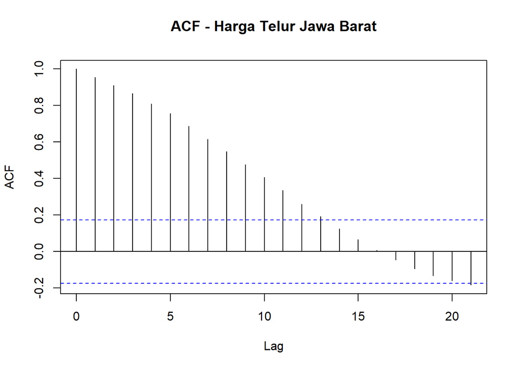

```r
harga_train <- na.omit(train_data$Jawa.Barat)
acf(harga_train, main = "ACF - Harga Telur Jawa Barat")
```

Berdasarkan plot ACF, terlihat bahwa plot ACF pada data tersebut cenderung tails off.

### Uji ADF

$H_0$: Data tidak stasioner dalam rataan

$H_1$: Data stasioner dalam rataan

```r
tseries::adf.test(harga_train)
```

```
##
##  Augmented Dickey-Fuller Test
##
## data:  harga_train
## Dickey-Fuller = -2.9681, Lag order = 5, p-value = 0.1741
## alternative hypothesis: stationary
```

### Plot Box Cox

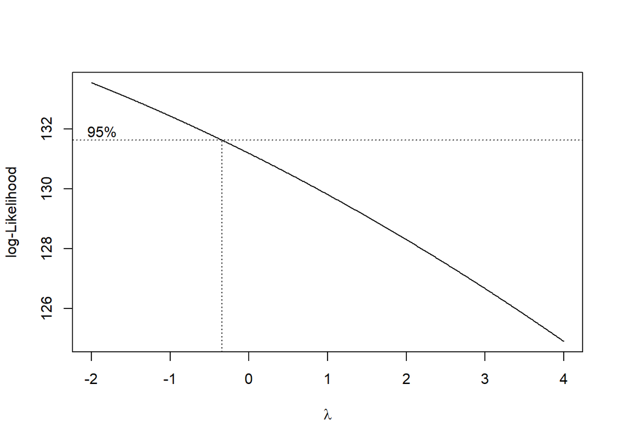

```r
index <- seq_along(harga_train)

# Plot Box-Cox
bc_train <- boxcox(harga_train ~ index, lambda = seq(-2, 4, by = 0.01))
```

```r
# Nilai lambda maksimum (optimum)
lambda_train <- bc_train$x[which.max(bc_train$y)]
lambda_train
```

```
## [1] -2
```

```r
# Hitung selang kepercayaan 95%

# CI lambda: nilai log-likelihood maksimum - chi-square
ci_lambda_train <- bc_train$x[bc_train$y > max(bc_train$y) - 0.5 * qchisq(0.95, 1)]

# Batas bawah dan atas
ci_lower_train <- min(ci_lambda_train)
ci_upper_train <- max(ci_lambda_train)

# Tampilkan hasil
c(Batas_Bawah = ci_lower_train, Batas_Atas = ci_upper_train)
```

```
## Batas_Bawah  Batas_Atas
##       -2.00       -0.35
```

Gambar di atas menunjukkan nilai λ optimum (rounded value) sebesar -2 dan selang kepercayaan 95% nilai memiliki batas bawah -2 dan batas atas -0,35. Selang tersebut *tidak memuat nilai satu* sehingga dapat dikatakan bahwa data harga *tidak stasioner dalam ragam*.

### Transformasi Box-Cox

```r
model_bc_train <- lm(harga_train ~ 1)
```

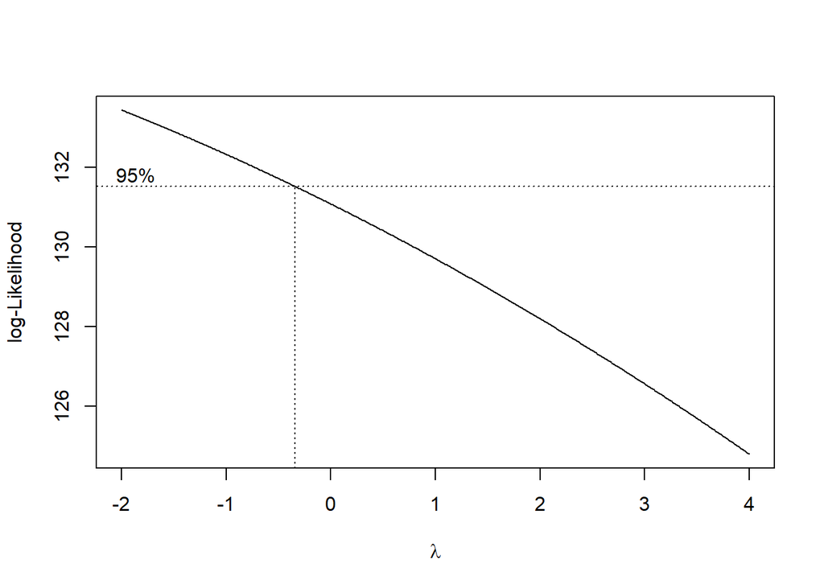

```r
bc_train2 <- boxcox(model_bc_train, lambda = seq(-2, 4, by = 0.01))
```

```r
lambda_opt3 <- bc$x[which.max(bc$y)]
lambda_opt3
```

```
## [1] -2
```

```r
ci_lambda3 <- bc_train2$x[bc_train2$y > max(bc_train2$y) - 0.5 * qchisq(0.95, 1)]
ci_lower3 <- min(ci_lambda3)
ci_upper3 <- max(ci_lambda3)
```

```r
c(Batas_Bawah = ci_lower3, Batas_Atas = ci_upper3)
```

```
## Batas_Bawah  Batas_Atas
##       -2.00       -0.35
```

Gambar di atas menunjukkan nilai λ optimum (rounded value) sebesar -2 dan selang kepercayaan 95% nilai memiliki batas bawah -2 dan batas atas -0,35. Selang tersebut *tidak memuat nilai satu* sehingga dapat dikatakan bahwa data harga *tidak stasioner dalam ragam*.

### Differencing 1

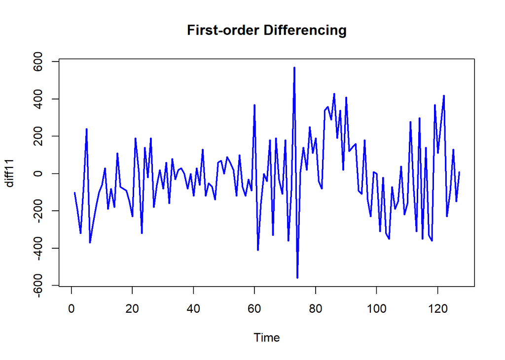

```r
diff11 <- diff(harga_train, differences = 1)
plot.ts(diff11, main = "First-order Differencing", col = "blue", lwd = 2)
```

```r
adf.test(diff11)
```

```
##
##  Augmented Dickey-Fuller Test
##
## data:  diff11
## Dickey-Fuller = -2.6561, Lag order = 5, p-value = 0.3038
## alternative hypothesis: stationary
```

p-value > 0,05 sehingga masih tidak stasioner, maka akan coba differencing ke 2 kali.

### Differencing 2

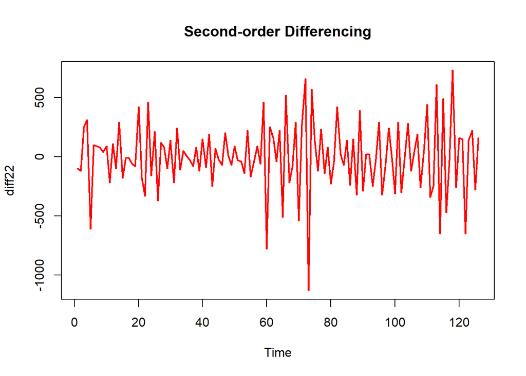

```r
diff22 <- diff(harga_train, differences = 2)
plot.ts(diff22, main = "Second-order Differencing", col = "red", lwd = 2)
```

```r
adf.test(diff22)
```

```
##
##  Augmented Dickey-Fuller Test
##
## data:  diff22
## Dickey-Fuller = -8.3348, Lag order = 4, p-value = 0.01
## alternative hypothesis: stationary
```

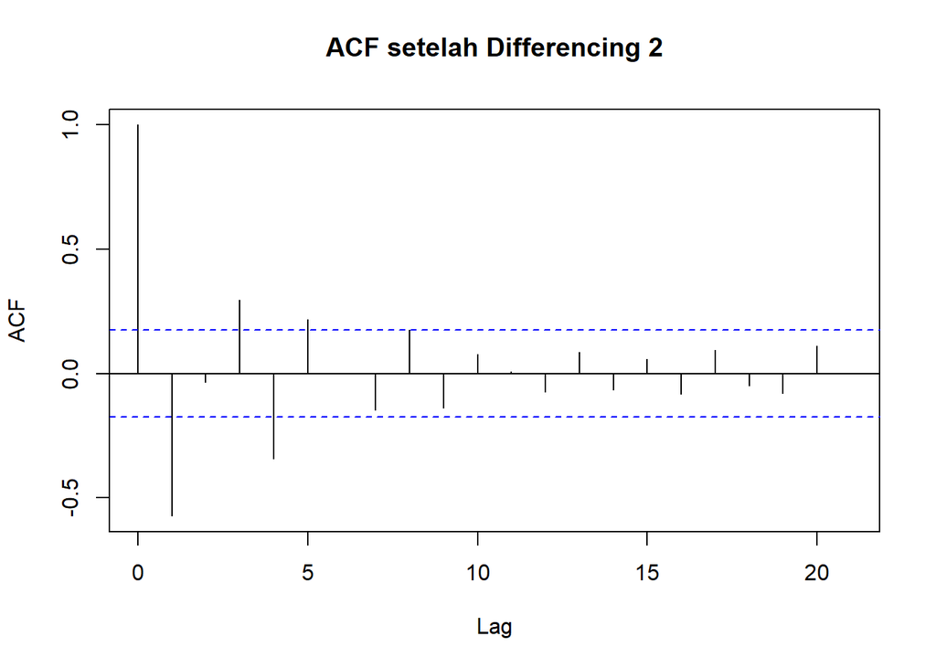

```r
acf(diff22, main = "ACF setelah Differencing 2")
```

Data sudah stasioner terhadap rataan, namun masih non stasioner terhadap ragam.

## Data Test

```r
test_data$Date <- as.Date(test_data$Date)
```

### Plot Time Series

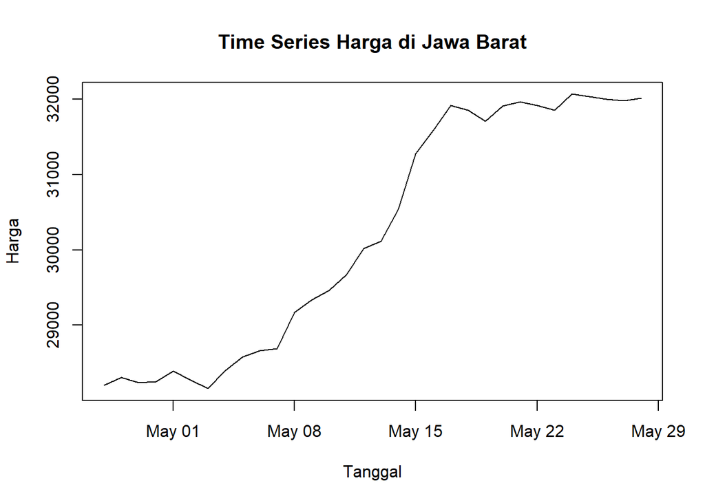

```r
plot(test_data$Date, test_data$Jawa.Barat, type = "l",
     xlab = "Tanggal", ylab = "Harga", main = "Time Series Harga di Jawa Barat")
```

```r
mean(test_data$Jawa.Barat, na.rm = TRUE)
```

```
## [1] 30206.25
```

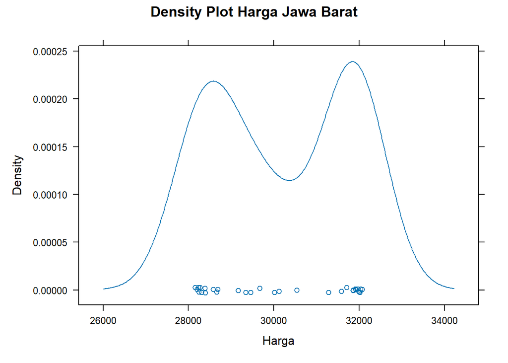

```r
densityplot(as.vector(test_data$Jawa.Barat),
            main = "Density Plot Harga Jawa Barat",
            xlab = "Harga")
```

Plot Time Series dan Density Plot di atas menunjukkan bahwa data tidak stasioner terhadap rataan.

### Plot ACF

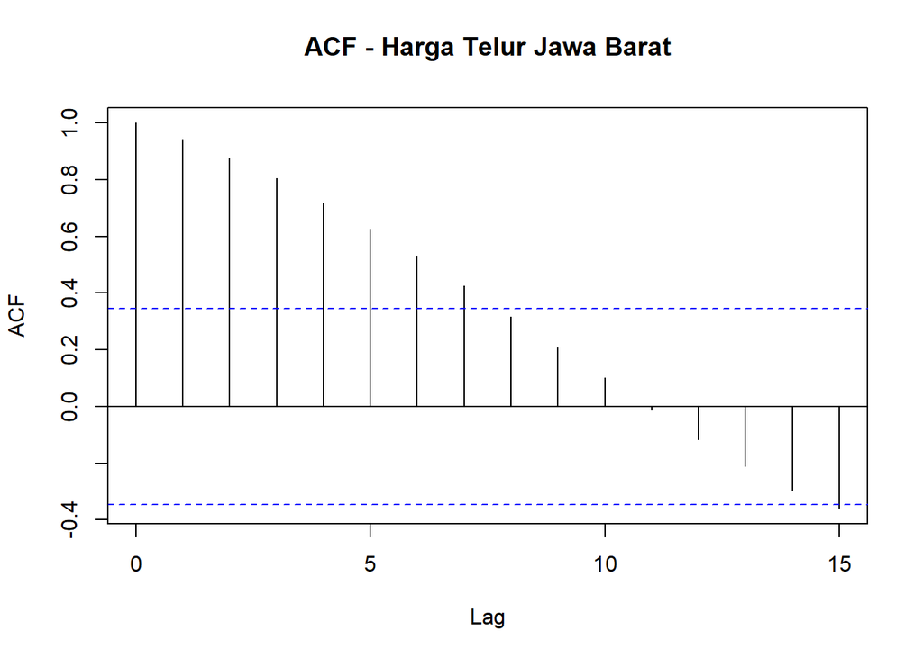

```r
harga_test <- na.omit(test_data$Jawa.Barat)
acf(harga_test, main = "ACF - Harga Telur Jawa Barat")
```

Berdasarkan plot ACF, terlihat bahwa plot ACF pada data tersebut cenderung tails off.

### Uji ADF

$H_0$: Data tidak stasioner dalam rataan

$H_1$: Data stasioner dalam rataan

```r
tseries::adf.test(harga_test)
```

```
##
##  Augmented Dickey-Fuller Test
##
## data:  harga_test
## Dickey-Fuller = -1.8229, Lag order = 3, p-value = 0.6412
## alternative hypothesis: stationary
```

### Plot Box Cox

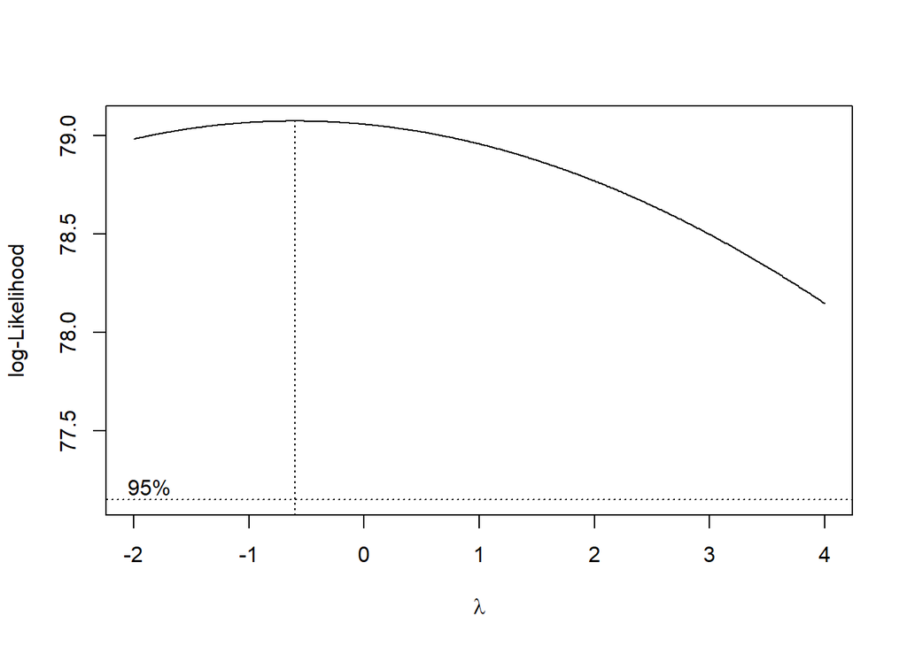

```r
index <- seq_along(harga_test)

# Plot Box-Cox
bc_test <- boxcox(harga_test ~ index, lambda = seq(-2, 4, by = 0.01))
```

```r
# Nilai lambda maksimum (optimum)
lambda_test <- bc_test$x[which.max(bc_test$y)]
lambda_test
```

```
## [1] -0.6
```

```r
# Hitung selang kepercayaan 95%

# CI lambda: nilai log-likelihood maksimum - chi-square
ci_lambda_test <- bc_test$x[bc_test$y > max(bc_test$y) - 0.5 * qchisq(0.95, 1)]

# Batas bawah dan atas
ci_lower_test <- min(ci_lambda_test)
ci_upper_test <- max(ci_lambda_test)

# Tampilkan hasil
c(Batas_Bawah = ci_lower_test, Batas_Atas = ci_upper_test)
```

```
## Batas_Bawah  Batas_Atas
##          -2           4
```